# Trình bày và mô tả dữ liệu (buổi 1)

#### 3.3. Tổ chức đồ (histogram):

Dùng để biểu thị tần số/ tần suất các giá trị trong mỗi khoảng giá trị. Để vẽ tổ chức đồ ta dùng hàm **hist**:

**hist(x, breaks, freq, include.lowest, right, col, border, main, xlim, ylim, xlab, ylab, labels)**

trong đó,

**x:** véc tơ dữ liệu dạng số cần vẽ biểu đồ.

**freq:** dạng logic, nếu **freq = TRUE** các cột của biểu đồ mô tả tần số, nếu **freq = FALSE** các cột của biểu đồ mô tả tần suất mật độ.

**breaks:** véc tơ số (ít nhất hai tọa độ) gồm các điểm chia giữa các cột hoặc là một số nguyên dương (lớn hơn hoặc bằng 2) chỉ số cột của biểu đồ.

**right:** dạng logic, nếu **right = TRUE** thì các cột lấy phần tử trong khoảng dạng (a; b], nếu **right = FALSE** thì trong khoảng dạng [a; b), mặc định **right = TRUE.**

**include.lowest:** dạng logic, nếu **include.lowest = TRUE** thì cột đầu tiên chứa giá trị nhỏ nhất của các điểm chia (khi **right = TRUE**) hoặc cột cuối cùng chứa giá trị lớn nhất của các điểm chia (khi **right = FALSE**), mặc định **include.lowest = TRUE.**

**col:** màu của các cột.

**border:** màu đường biên của các cột.

**main,xlab,ylab:** tên của biểu đồ, tên trục x; y.

**xlim,ylim:** giới hạn trên các trục.

**labels:** dạng logic hoặc dạng kí tự điền tên trên đỉnh mỗi cột.

*Ví dụ:* Vẽ tổ chức đồ cho cột Tuổi.

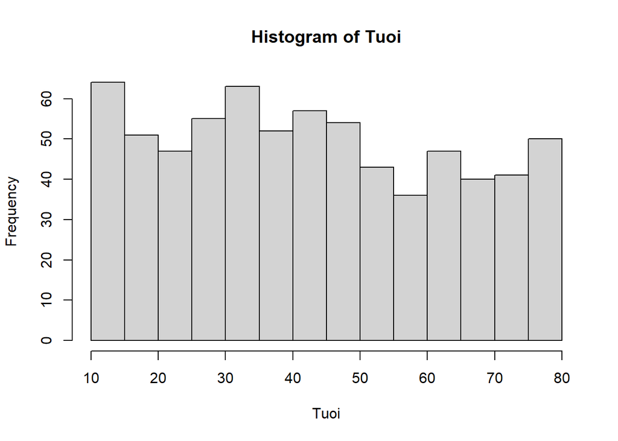

```r
Tuoi = sample(10:80,700, replace = T)
hist(Tuoi)
```

Ta cũng có thể điều chỉnh biểu đồ để phù hợp với số liệu và sinh động hơn bằng các lệnh:

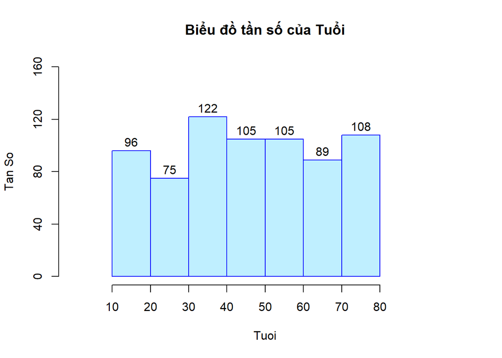

```r
Tuoi = sample(10:80,700, replace = T)
hist(Tuoi, xlim = c(0,100), ylim = c(0,160), breaks = seq(10,80,10),right = T, xlab = "Tuoi", ylab = "Tan So", xaxt = "n", yaxt = "n", labels = T, main = "Biểu đồ tần số của Tuổi", col = "lightblue1", border = "blue1")
#Điền số trên các trục
axis(side = 1, c(10, 20, 30, 40, 50, 60, 70, 80))
axis(side = 2, c(0,40,80,120,160))
```

#### 3.4. Biểu đồ tròn:

Dùng để phân tích hoặc so sánh ở mức độ tổng thể. Trong R để vẽ biểu đồ hình tròn ta dùng hàm **pie**:

**pie(x, labels, col, border, lty, main, sub)**

trong đó:

**x:** véc tơ dạng số thể hiện giá trị của mỗi hình quạt trong biểu đồ.

**labels:** tên của những hình quạt trong biểu đồ.

**col:** màu của các hình quạt.

**border:** màu của đường ranh giới giữa các hình quạt.

**lty:** kiểu nét vẽ của đường ranh giới giữa các hình quạt.

**main,sub:** tiêu đề và tiêu đề phụ của biểu đồ.

*Ví dụ.* Ta dùng biểu đồ hình tròn minh họa diện tích của mỗi châu so với toàn bộ diện tích trên thế giới được vẽ qua đoạn lệnh sau:

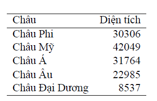

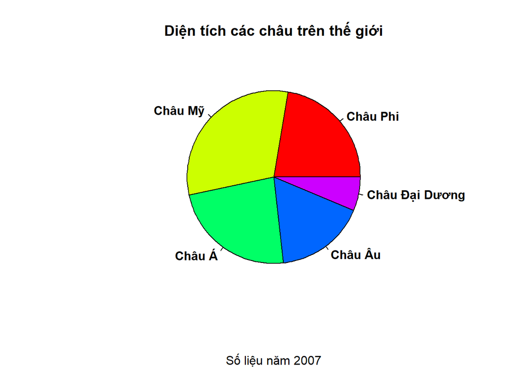

```r
DienTich = c(30306, 42049, 31764, 22985, 8537)
TenChau = c("Châu Phi", "Châu Mỹ", "Châu Á", "Châu Âu", "Châu Đại Dương")
pie(DienTich, col=rainbow(5), labels = TenChau, font=2, main="Diện tích các châu trên thế giới", sub="Số liệu năm 2007")
```

Nếu muốn điền phần trăm (%) diện tích của từng châu so với toàn bộ diện tích trên thế giới, ta có thể làm như sau:

```r
DienTich = c(30306, 42049, 31764, 22985, 8537)
#Tính tỉ lệ phần trăm
TiLe = round(prop.table(DienTich),3)*100
TiLe
```

```
## [1] 22.3 31.0 23.4 16.9  6.3
```

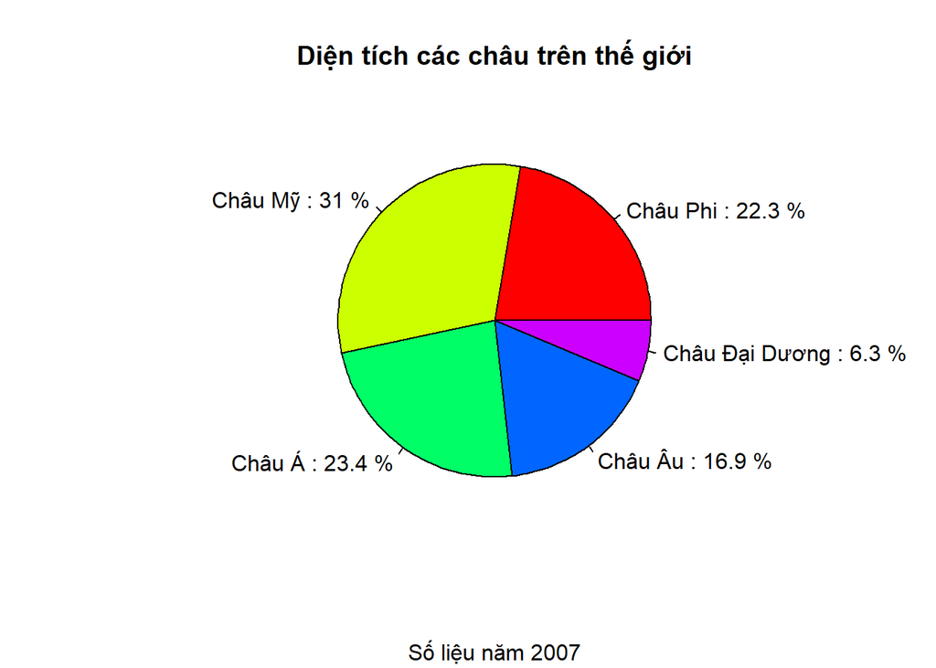

```r
TenChau = c("Châu Phi", "Châu Mỹ", "Châu Á", "Châu Âu", "Châu Đại Dương")
pie(DienTich, col=rainbow(5), labels = paste(TenChau, ":" ,TiLe,"%"))
#Viết tên biểu đồ riêng
title(main="Diện tích các châu trên thế giới", sub="Số liệu năm 2007", font = 2)
```

#### 3.4.Biểu đồ tán xạ:

Dùng để quan sát mối liên hệ giữa hai biến. Trong R biểu đồ tán xạ được vẽ qua hàm **plot** với tham số **type=“p”**. Một số tham số cần thiết của hàm **plot** trong trường hợp này được cho như sau:

**plot (x, y, type = “p”, main = ““, xlab =”“, ylab =”“, bty =”l”)**

trong đó:

**x, y** tương ứng là véc tơ tọa độ của biến định lượng thứ nhất, thứ hai;

**main, xlab, ylab** tên của biểu đồ, tên biến thứ nhất, biến thứ hai;

**type = “p”** kiểu vẽ gồm các điểm trên mặt phẳng;

**bty = “l”** kiểu bao quanh biểu đồ giống hai trục tọa độ đề các Oxy.

*Ví dụ.* Ta dùng biểu đồ tán xạ để mô tả mối quan hệ giữa chi phí và số khách như sau:

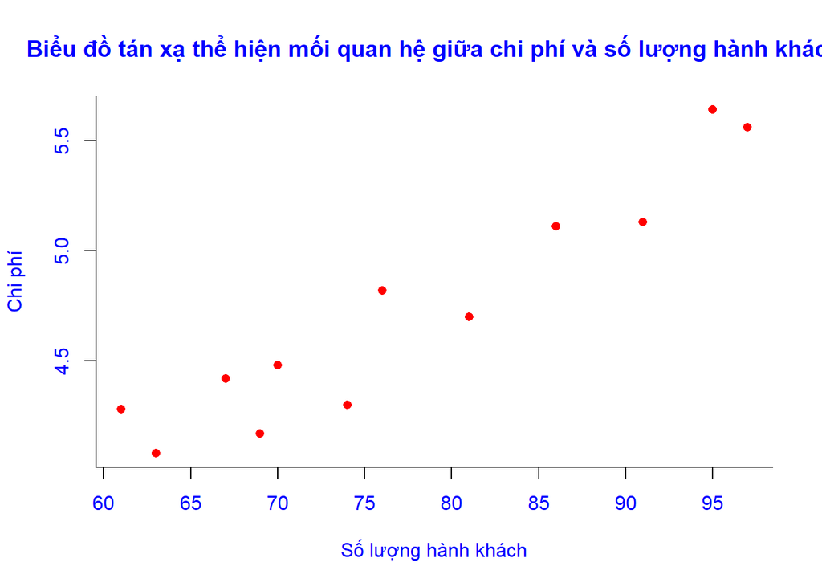

```r
SoKhach = c(61 ,63 ,67 ,69 ,70 ,74 ,76 ,81 ,86 ,91 ,95, 97)
ChiPhi = c(4.28, 4.08, 4.42, 4.17, 4.48, 4.30, 4.82, 4.70, 5.11, 5.13, 5.64, 5.56)
plot(SoKhach, ChiPhi, main = "Biểu đồ tán xạ thể hiện mối quan hệ giữa chi phí và số lượng hành khách",xlab="Số lượng hành khách",ylab="Chi phí", bty = "l", type = "p", pch = 16, col="red", col.main = "blue", col.lab="blue", col.axis = "blue")
```

Ngoài ra, ta cũng có thể vẽ biểu đồ dạng đường như sau:

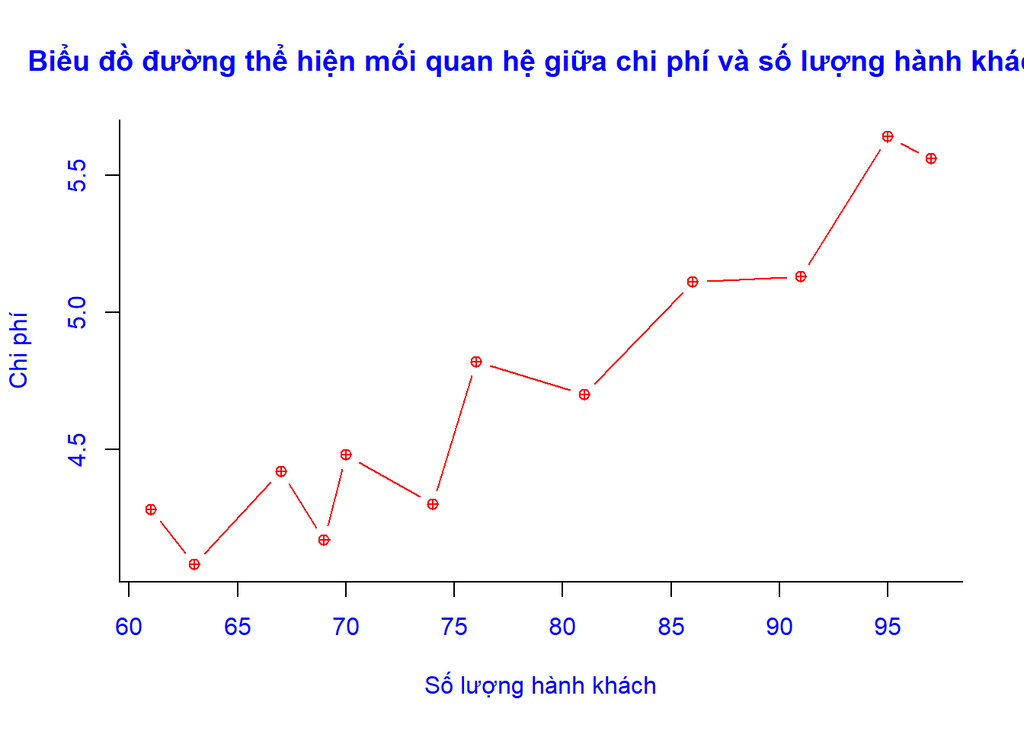

```r
plot(SoKhach, ChiPhi, main = "Biểu đồ đường thể hiện mối quan hệ giữa chi phí và số lượng hành khách",xlab="Số lượng hành khách",ylab="Chi phí", bty = "l", type = "b", pch = 10, col="red", col.main = "blue", col.lab="blue", col.axis = "blue")
```

#### 3.5. Lưu hình đã vẽ trong Rstudio:

Sử dụng các hàm **pdf() , png() , jpeg(),…** để mở 1 file, ta sẽ sử dụng file này để lưu biểu đồ.

**pdf(filename, width, height, units, bg)**: pdf file

**png(filename, width, height, units, bg)**: png file

**jpeg(filename, width, height, units, quality, bg)**: jpeg file

trong đó,

**filename:** tên của tệp đầu ra.

**width:** chiều rộng của thiết bị, mặc định là 480px.

**height:** chiều cao của thiết bị, mặc định là 480px.

**units:** đơn vị của chiều cao và chiều rộng, có thể là inches, px(pixels), cm, mm, mặc định đơn vị là px.

**bg:** màu của nền hình vẽ, mặc định là màu trắng.

**quality:** phần trăm chỉ chất lượng của ảnh dạng JPEG, mặc định là 75%.

```r
#Chọn thư mục để lưu hình vẽ
setwd("D:/Introduction to Data Analysis/Finals")
#Tạo thiết bị đồ họa dạng .jpeg
jpeg(filename = "Chi phí và số lượng hành khách.jpeg")
#Thực hiện các thao tác vẽ hình
SoKhach = c(61 ,63 ,67 ,69 ,70 ,74 ,76 ,81 ,86 ,91 ,95, 97)
ChiPhi = c(4.28, 4.08, 4.42, 4.17, 4.48, 4.30, 4.82, 4.70, 5.11, 5.13, 5.64, 5.56)
plot(SoKhach, ChiPhi, main = "Biểu đồ tán xạ thể hiện mối quan hệ giữa chi phí và số lượng hành khách",xlab="Số lượng hành khách",ylab="Chi phí", bty = "l", type = "b", pch = 16, col="red", col.main = "blue", col.lab="blue", col.axis = "blue")
# Đóng thiết bị đồ họa
dev.off()
```